# HW191019

# Chapter 9. Tidy data with tidyr

## Tidy data

### Q1

Each variable should be put in a seperate volumn, and observations are arranged in rows.

### Q2

table2:

```r
cases <- table2 %>%
  group_by(country, year) %>%
  filter(type == "cases") %>%
  rename(cases = count)
population <- table2 %>%
  group_by(country, year) %>%
  filter(type == "population") %>%
  rename(population = count)
table2.1 <- tibble(country = cases$ country, year = cases$year, cases = cases$cases, population = population$population) %>%
  mutate(rate = cases / population * 10000)
table2.1
```

```
## # A tibble: 6 x 5
##   country      year  cases population  rate
##   <chr>       <int>  <int>      <int> <dbl>
## 1 Afghanistan  1999    745   19987071 0.373
## 2 Afghanistan  2000   2666   20595360 1.29
## 3 Brazil       1999  37737  172006362 2.19
## 4 Brazil       2000  80488  174504898 4.61
## 5 China        1999 212258 1272915272 1.67
## 6 China        2000 213766 1280428583 1.67
```

table4a & 4b:

```r
table4.1 <- tibble(country = table4a$country, "1999rate" = table4a[['1999']] / table4b[['1999']] * 10000, "2000rate" = table4a[['2000']] / table4b[['2000']] * 10000)
table4.1
```

```
## # A tibble: 3 x 3
##   country     `1999rate` `2000rate`
##   <chr>            <dbl>      <dbl>
## 1 Afghanistan      0.373       1.29
## 2 Brazil           2.19        4.61
## 3 China            1.67        1.67
```

### Q3

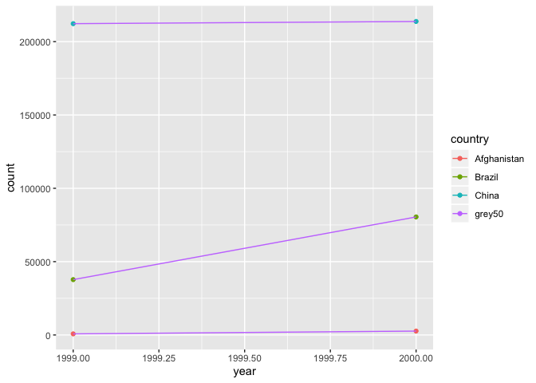

```r
table2 %>%
  filter(type == "cases") %>%
  ggplot(aes(year, count)) +
  geom_point(aes(color = country)) +
  geom_line(aes(group = country, color = "grey50"))
```

We need to find out the values of cases first.

## Gathering and spreading

### Q1

```r
stocks <- tibble(
year =c(2015,2015,2016,2016), half=c(1, 2, 1, 2), return = c(1.88, 0.59, 0.92, 0.17)
)
stocks
```

```
## # A tibble: 4 x 3
##    year  half return
##   <dbl> <dbl>  <dbl>
## 1  2015     1   1.88
## 2  2015     2   0.59
## 3  2016     1   0.92
## 4  2016     2   0.17
```

```r
stocks1 <- spread(stocks, key = half, value = return)
stocks1
```

```
## # A tibble: 2 x 3
##    year   `1`   `2`
##   <dbl> <dbl> <dbl>
## 1  2015  1.88  0.59
## 2  2016  0.92  0.17
```

```r
stocks1 %>%
  gather(key = "half", value = "return",  '1', '2')
```

```
## # A tibble: 4 x 3
##    year half  return
##   <dbl> <chr>  <dbl>
## 1  2015 1       1.88
## 2  2016 1       0.92
## 3  2015 2       0.59
## 4  2016 2       0.17
```

The data type of the column is lost (half change from dbl to chr)

```r
stocks %>%
  spread(key = "half", value = "return") %>%
  gather('1', '2', key = "half", value = "return", convert = TRUE)
```

```
## # A tibble: 4 x 3
##    year  half return
##   <dbl> <int>  <dbl>
## 1  2015     1   1.88
## 2  2016     1   0.92
## 3  2015     2   0.59
## 4  2016     2   0.17
```

Convert turns the half to integers. Convert guesses the data type.

### Q2

You need to add “” around the 1999 and 2000 so that they can be interpreted as names.

### Q3

```r
people <- tribble(
  ~name, ~key, ~value,
  #-----------------|--------|------
  "Phillip Woods", "age", 45,
  "Phillip Woods", "height", 186,
  "Phillip Woods", "age", 50,
  "Jessica Cordero", "age", 37,
  "Jessica Cordero", "height", 156
)
```

spread(people, key, value) There are two values corresponding to Phillip Woods’ age.

```r
people1 <- people %>%
  group_by(name, key) %>%
  mutate(obs = row_number())
people1
```

```
## # A tibble: 5 x 4
## # Groups:   name, key [4]
##   name            key    value   obs
##   <chr>           <chr>  <dbl> <int>
## 1 Phillip Woods   age       45     1
## 2 Phillip Woods   height   186     1
## 3 Phillip Woods   age       50     2
## 4 Jessica Cordero age       37     1
## 5 Jessica Cordero height   156     1
```

```r
spread(people1, key, value)
```

```
## # A tibble: 3 x 4
## # Groups:   name [2]
##   name              obs   age height
##   <chr>           <int> <dbl>  <dbl>
## 1 Jessica Cordero     1    37    156
## 2 Phillip Woods       1    45    186
## 3 Phillip Woods       2    50     NA
```

### Q4

```r
preg <- tribble(
~pregnant, ~male, ~female, "yes", NA, 10, "no", 20, 12
)
preg
```

```
## # A tibble: 2 x 3
##   pregnant  male female
##   <chr>    <dbl>  <dbl>
## 1 yes         NA     10
## 2 no          20     12
```

```r
preg1 <- preg %>%
  gather(male, female, key = "sex", value ="count")
preg1
```

```
## # A tibble: 4 x 3
##   pregnant sex    count
##   <chr>    <chr>  <dbl>
## 1 yes      male      NA
## 2 no       male      20
## 3 yes      female    10
## 4 no       female    12
```

## Separate and unite

### Q1

```r
tibble(x = c("a,b,c", "d,e,f,g", "h,i,j")) %>%
    separate(x, c("one", "two", "three"), extra = "merge")
```

```
## # A tibble: 3 x 3
##   one   two   three
##   <chr> <chr> <chr>
## 1 a     b     c
## 2 d     e     f,g
## 3 h     i     j
```

Extra: default is dropping the extra piece and giving a warning = “drop”: simply drop the values = “merge”: put the extras into the last column.

```r
tibble(x = c("a,b,c", "d,e", "f,g,i")) %>%
    separate(x, c("one", "two", "three"), fill = "left")
```

```
## # A tibble: 3 x 3
##   one   two   three
##   <chr> <chr> <chr>
## 1 a     b     c
## 2 <NA>  d     e
## 3 f     g     i
```

Fill: when there is not enought pieces default is give a warning and fill from the right with NA. = “right”: fill from the right = “left”: fill from the left

### Q2

```r
table5 %>%
    unite(Year, century, year, sep = "", remove = F)
```

```
## # A tibble: 6 x 5
##   country     Year  century year  rate
##   <chr>       <chr> <chr>   <chr> <chr>
## 1 Afghanistan 1999  19      99    745/19987071
## 2 Afghanistan 2000  20      00    2666/20595360
## 3 Brazil      1999  19      99    37737/172006362
## 4 Brazil      2000  20      00    80488/174504898
## 5 China       1999  19      99    212258/1272915272
## 6 China       2000  20      00    213766/1280428583
```

“remove” removes the input values from the table. When you want to keep the old variables you can set it to FALSE.

### Q3

separate() split a column by identifying the separator, while extract() split a column by identifying the entry as following a general form with some groups within. Because you can choose how to divide a column, but when uniting you can only choose the type of sepearator to put between.

## Missing Values

### Q1

```r
stocks %>%
  spread(year, return, fill = "N")
```

```
## # A tibble: 2 x 3
##    half `2015` `2016`
##   <dbl> <chr>  <chr>
## 1     1 1.88   0.92
## 2     2 0.59   0.17
```

```r
stocks %>%
  complete(year, fill = list("N","A"))
```

```
## # A tibble: 4 x 3
##    year  half return
##   <dbl> <dbl>  <dbl>
## 1  2015     1   1.88
## 2  2015     2   0.59
## 3  2016     1   0.92
## 4  2016     2   0.17
```

it can fill a list in the complete()

### Q2

```r
stocks %>%
  fill(return, .direction = "up")
```

```
## # A tibble: 4 x 3
##    year  half return
##   <dbl> <dbl>  <dbl>
## 1  2015     1   1.88
## 2  2015     2   0.59
## 3  2016     1   0.92
## 4  2016     2   0.17
```

It specify whether to fill NA with the previous or next value.

## WHO Case Study

### Q1

```r
who %>%
  filter(new_sp_m014 == 0) %>%
  nrow()
```

```
## [1] 862
```

There is 0 cases. So missing value (NA) probably doesn’t mean 0 case occurs for that category; it means WHO don’t have the data. Thus it’s reasonable to ignore it.

### 2

```r
who
```

```
## # A tibble: 7,240 x 60
##    country iso2  iso3   year new_sp_m014 new_sp_m1524 new_sp_m2534
##    <chr>   <chr> <chr> <int>       <int>        <int>        <int>
##  1 Afghan~ AF    AFG    1980          NA           NA           NA
##  2 Afghan~ AF    AFG    1981          NA           NA           NA
##  3 Afghan~ AF    AFG    1982          NA           NA           NA
##  4 Afghan~ AF    AFG    1983          NA           NA           NA
##  5 Afghan~ AF    AFG    1984          NA           NA           NA
##  6 Afghan~ AF    AFG    1985          NA           NA           NA
##  7 Afghan~ AF    AFG    1986          NA           NA           NA
##  8 Afghan~ AF    AFG    1987          NA           NA           NA
##  9 Afghan~ AF    AFG    1988          NA           NA           NA
## 10 Afghan~ AF    AFG    1989          NA           NA           NA
## # ... with 7,230 more rows, and 53 more variables: new_sp_m3544 <int>,
## #   new_sp_m4554 <int>, new_sp_m5564 <int>, new_sp_m65 <int>,
## #   new_sp_f014 <int>, new_sp_f1524 <int>, new_sp_f2534 <int>,
## #   new_sp_f3544 <int>, new_sp_f4554 <int>, new_sp_f5564 <int>,
## #   new_sp_f65 <int>, new_sn_m014 <int>, new_sn_m1524 <int>,
## #   new_sn_m2534 <int>, new_sn_m3544 <int>, new_sn_m4554 <int>,
## #   new_sn_m5564 <int>, new_sn_m65 <int>, new_sn_f014 <int>,
## #   new_sn_f1524 <int>, new_sn_f2534 <int>, new_sn_f3544 <int>,
## #   new_sn_f4554 <int>, new_sn_f5564 <int>, new_sn_f65 <int>,
## #   new_ep_m014 <int>, new_ep_m1524 <int>, new_ep_m2534 <int>,
## #   new_ep_m3544 <int>, new_ep_m4554 <int>, new_ep_m5564 <int>,
## #   new_ep_m65 <int>, new_ep_f014 <int>, new_ep_f1524 <int>,
## #   new_ep_f2534 <int>, new_ep_f3544 <int>, new_ep_f4554 <int>,
## #   new_ep_f5564 <int>, new_ep_f65 <int>, newrel_m014 <int>,
## #   newrel_m1524 <int>, newrel_m2534 <int>, newrel_m3544 <int>,
## #   newrel_m4554 <int>, newrel_m5564 <int>, newrel_m65 <int>,
## #   newrel_f014 <int>, newrel_f1524 <int>, newrel_f2534 <int>,
## #   newrel_f3544 <int>, newrel_f4554 <int>, newrel_f5564 <int>,
## #   newrel_f65 <int>
```

```r
who1 <- who %>%
  gather(new_sp_m014:newrel_f65, key = "key", value = "cases",
na.rm = TRUE) %>%
  separate(key, c("new", "type", "sexage"), sep = "_") %>%
  select(-new) %>%
  separate("sexage", c("sex", "age"), sep = 1)
```

```
## Warning: Expected 3 pieces. Missing pieces filled with `NA` in 2580 rows
## [73467, 73468, 73469, 73470, 73471, 73472, 73473, 73474, 73475, 73476,
## 73477, 73478, 73479, 73480, 73481, 73482, 73483, 73484, 73485, 73486, ...].
```

```r
who1
```

```
## # A tibble: 76,046 x 8
##    country     iso2  iso3   year type  sex   age   cases
##    <chr>       <chr> <chr> <int> <chr> <chr> <chr> <int>
##  1 Afghanistan AF    AFG    1997 sp    m     014       0
##  2 Afghanistan AF    AFG    1998 sp    m     014      30
##  3 Afghanistan AF    AFG    1999 sp    m     014       8
##  4 Afghanistan AF    AFG    2000 sp    m     014      52
##  5 Afghanistan AF    AFG    2001 sp    m     014     129
##  6 Afghanistan AF    AFG    2002 sp    m     014      90
##  7 Afghanistan AF    AFG    2003 sp    m     014     127
##  8 Afghanistan AF    AFG    2004 sp    m     014     139
##  9 Afghanistan AF    AFG    2005 sp    m     014     151
## 10 Afghanistan AF    AFG    2006 sp    m     014     193
## # ... with 76,036 more rows
```

It gives out a warning, because it cannot sort out new_rel using that separate method.

### Q3

```r
select(who1, country, iso2, iso3) %>%
  distinct() %>%
  group_by(country) %>%
  filter(n() > 1)
```

```
## # A tibble: 0 x 3
## # Groups:   country [0]
## # ... with 3 variables: country <chr>, iso2 <chr>, iso3 <chr>
```

There is no distinct combination of iso2 and iso3 for each country, so iso2 and iso3 are indeed only abbr.

### Q4

```r
who2 <- who1 %>%
  group_by(country, year, sex) %>%
  summarise(cases = sum(cases)) %>%
  unite(countrysex, country, sex, remove = F) %>%
  filter(year > 1995)
```

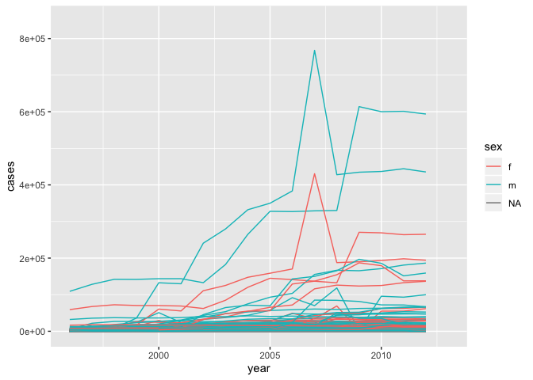

```r
ggplot(who2, aes(x = year, y = cases, group = countrysex, colour = sex)) +
  geom_line()
```

# Chapter 10 Relational Data with dplyr

## nycflights13

### Q1

flights and airports; flights give you the flights of plane and its departing and arriving airports, while airports gives the longitude and latitude of those airports. origin&dest in flights and faa&lat&lon in airports.

### Q2

origin in weather –> faa in airports

### Q4

```r
holidays <- tribble(
  ~name, ~year, ~month, ~day,
  "New year", 2013, 01, 01,
  "July 4th", 2013, 07, 04,
  "Thanksgiving", 2013, 11, 29,
  "Chrismas", 2013, 12, 25
)
```

Date and name. Date can be used to map to existing tables.

## Keys

### Q1

```r
flights1 <- flights %>%
  arrange(year, month, day, sched_dep_time, flight) %>%
  mutate(id = row_number())
flights1 %>%
  distinct() %>%
  group_by(id) %>%
  filter(n() > 1)
```

```
## # A tibble: 0 x 20
## # Groups:   id [0]
## # ... with 20 variables: year <int>, month <int>, day <int>,
## #   dep_time <int>, sched_dep_time <int>, dep_delay <dbl>, arr_time <int>,
## #   sched_arr_time <int>, arr_delay <dbl>, carrier <chr>, flight <int>,
## #   tailnum <chr>, origin <chr>, dest <chr>, air_time <dbl>,
## #   distance <dbl>, hour <dbl>, minute <dbl>, time_hour <dttm>, id <int>
```

### Q2

1. playerID, teamID, yearID, and stint

```r
Batting <- Lahman::Batting
Batting
```

[output not shown]

[output cut: 9078 more lines]

```r
Batting %>%
  distinct() %>%
  group_by(playerID, teamID, yearID, stint) %>%
  filter(n() > 1)
```

```
## # A tibble: 0 x 22
## # Groups:   playerID, teamID, yearID, stint [1]
## # ... with 22 variables: playerID <chr>, yearID <int>, stint <int>,
## #   teamID <fct>, lgID <fct>, G <int>, AB <int>, R <int>, H <int>,
## #   X2B <int>, X3B <int>, HR <int>, RBI <int>, SB <int>, CS <int>,
## #   BB <int>, SO <int>, IBB <int>, HBP <int>, SH <int>, SF <int>,
## #   GIDP <int>
```

```r
names <- babynames::babynames
names
```

```
## # A tibble: 1,924,665 x 5
##     year sex   name          n   prop
##    <dbl> <chr> <chr>     <int>  <dbl>
##  1  1880 F     Mary       7065 0.0724
##  2  1880 F     Anna       2604 0.0267
##  3  1880 F     Emma       2003 0.0205
##  4  1880 F     Elizabeth  1939 0.0199
##  5  1880 F     Minnie     1746 0.0179
##  6  1880 F     Margaret   1578 0.0162
##  7  1880 F     Ida        1472 0.0151
##  8  1880 F     Alice      1414 0.0145
##  9  1880 F     Bertha     1320 0.0135
## 10  1880 F     Sarah      1288 0.0132
## # ... with 1,924,655 more rows
```

```r
names %>%
  group_by(year, name, sex) %>%
  count() %>%
  filter(n > 1) %>%
  nrow()
```

```
## [1] 0
```

```r
atmos <- nasaweather::atmos
atmos
```

```
## # A tibble: 41,472 x 11
##      lat  long  year month surftemp  temp pressure ozone cloudlow cloudmid
##    <dbl> <dbl> <int> <int>    <dbl> <dbl>    <dbl> <dbl>    <dbl>    <dbl>
##  1  36.2 -114.  1995     1     273.  272.      835   304      7.5     34.5
##  2  33.7 -114.  1995     1     280.  282.      940   304     11.5     32.5
##  3  31.2 -114.  1995     1     285.  285.      960   298     16.5     26
##  4  28.7 -114.  1995     1     289.  291.      990   276     20.5     14.5
##  5  26.2 -114.  1995     1     292.  293.     1000   274     26       10.5
##  6  23.7 -114.  1995     1     294.  294.     1000   264     30        9.5
##  7  21.2 -114.  1995     1     295   295.     1000   258     29.5     11
##  8  18.7 -114.  1995     1     298.  297.     1000   252     26.5     17.5
##  9  16.2 -114.  1995     1     300.  298.     1000   250     27.5     18.5
## 10  13.7 -114.  1995     1     300.  299.     1000   250     26       16.5
## # ... with 41,462 more rows, and 1 more variable: cloudhigh <dbl>
```